# Visualization of Large Complex Data

Steve Elston

12/26/2020

# Review: Why is Perception Important?

- **Goal:** Communicate information visually
- Visualization technique maximize the information a viewer perceives
- limits of human perception are a significant factor in understanding complex relationships
- Can apply results of the considerable research on human perceptions for data visualization

# Use Aesthetics to Improve Perception

- Use aesthetics to improve perception
- We take a very broad view of the term ‘aesthetic’ here
- A plot aesthetics is any property of a visualization which highlight aspects of the data relationships
- Aesthetics are used to project additional dimensions of complex data onto the 2-dimensional plot surface

# Properties of Common Aesthetics

| Property or Aesthetic | Perception | Data Types |
| --- | --- | --- |
| Aspect ratio | Good | Numeric |
| Regression lines | Good | Numeric plus categorical |
| Marker position | Good | Numeric |
| Bar length | Good | Counts, numeric |
| Sequential color palette | Moderate | Numeric, ordered categorical |
| Marker size | Moderate | Numeric, ordered categorical |
| Line types | Limited | Categorical |
| Qualitative color palette | Limited | Categorical |
| Marker shape | Limited | Categorical |
| Area | Limited | Numeric or categorical |
| Angle | Limited | Numeric |

# Visualizing Large Complex Data is Difficult

**Problem:** Modern data sets are growing in size and complexity

- **Goal:** Understand key relationships in large complex data sets
- **Difficulty:** Large data volume
  - Modern computational systems have massive capacity
  - Example: Use map-reduce algorithms on cloud clusters
- **Difficulty:** Large numbers of variables
  - Huge number of variables with many potential relationships
  - **This is the hard part!**

# Limitation of Scientific Graphics

All scientific graphics are limited to a **2-dimensional projection**

- But, complex data sets have a great many dimensions
- We need methods to project large complex data onto 2-dimensions
- Generally, multiple views are required to understand complex data sets
  - Don’t expect one view to show all important relationships
  - Develop understanding over many views
  - Try many views, don’t expect most to be very useful

# Scalable Chart Types

Some chart types are inherently scalable.

- **Bar plots:** Counts can be computed; e.g. use map-reduce
- **Histograms:** Data is binned in parallel
- **Box plots:** Finding the quartiles is a scalable counting process
- **KDE and violin plots:** Similarly to the box plot, using kernel density estimation

# Over-plotting

**Over-plotting** occurs in plots when the markers lie one on another.

- Common, even in relatively small data sets
- Scatter plots can look like a blob and be completely uninterpretable
- Over-plotting is a significant problem in EDA and presentation graphics

# Dealing with Over-plotting

What can we do about over-plotting?

- **Marker transparency:** so one can see markers underneath; useful in cases with minimal overlap of markers
- **Marker size:** smaller marker size reduces over-plotting within limits
- **Adding jitter:** adding a bit of random **jitter** to variables with limited number of values

# Example of Overplotting

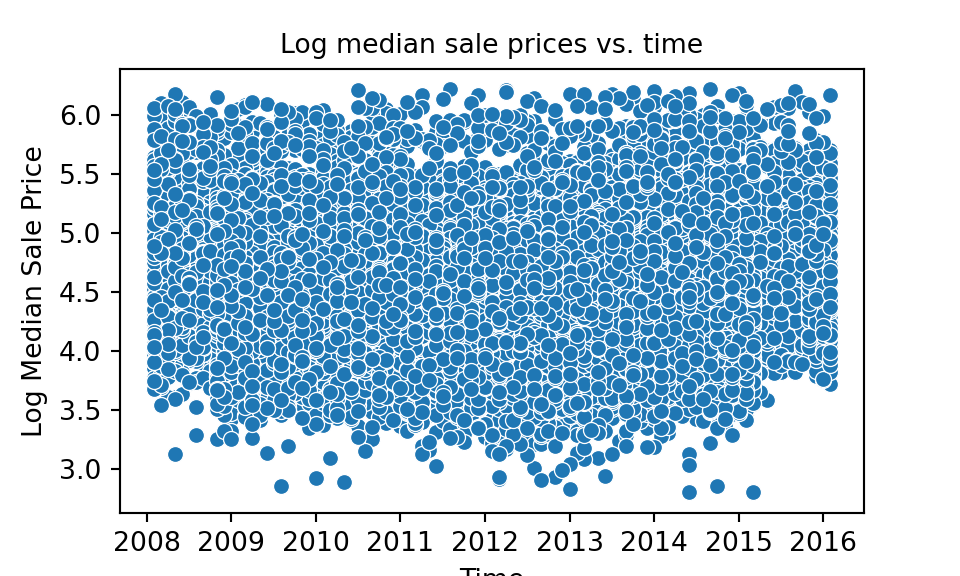

# Use Transparency, Marker Size, Downsampling

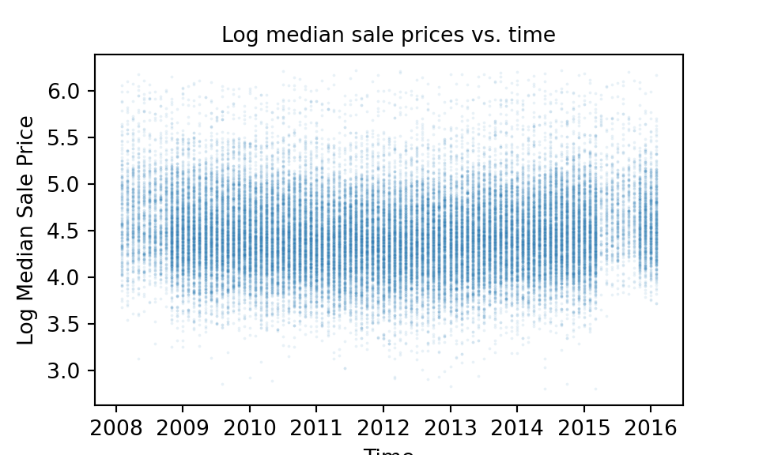

# Other Methods to Display Large Data Sets

Alternatives to avoid over-plotting for truly large data sets

- **Hex bin plots:** the 2-dimensional equivalent of the histogram
  - Frequency of values is tabulated into 2-dimensional hexagonal bins
  - Displayed using a sequential color palette
- **2-d kernel density estimation plots:** natural extension of the 1-dimensional KDE plot
  - Good for moderately large data
- **Heat map:** values of one variable against another
  - Categorical (count) or continuous variables
  - Carefully choose color pallet, sequential or divergent
- **Mosaic plots:** display multidimensional count (categorical) data
  - Uses tile size and color to project multiple dimensions
  - 2-d equivalent of a multi-variate bar chart
- **Dimensionality reduction:** we will discuss this later in the course

# Hexbin Plot

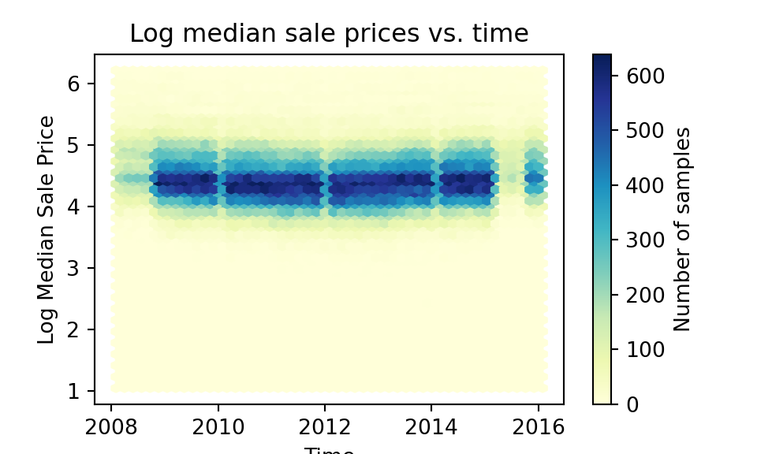

# Countour Plot

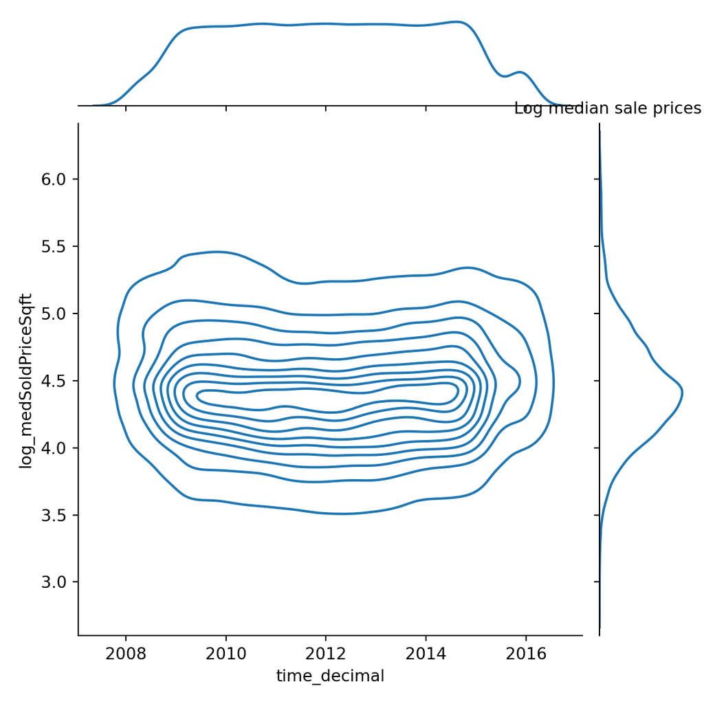

# Other Methods to Display Large Data Sets

Sometimes a **creative alternative** is best

- Often situation specific; many possibilities
- Finding a good one can require significant creativity!
- Example, choropleth for mutli-dimensional geographic data
- Example, time series of box plots

# Time Series of Box Plots

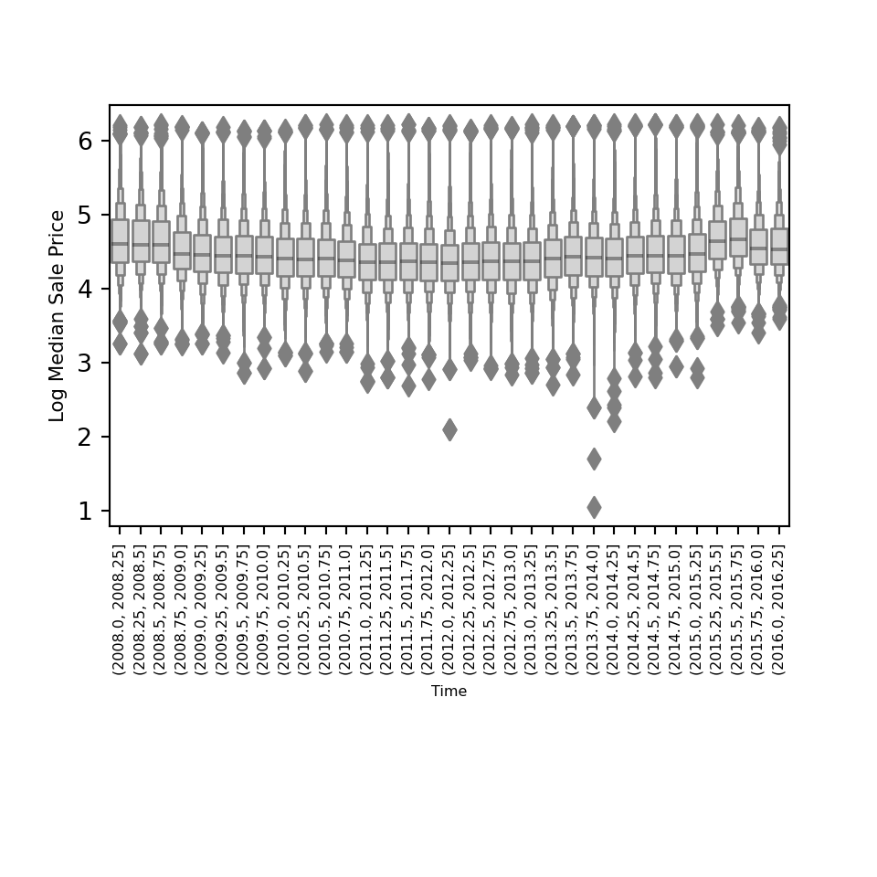

# Displays for Complex Data

How can we understand the relationships in complex data with many variables?

- **Arrays of plots:** subsets show relationships in a complex data set
- **Pairwise scatter plots:** matrix of all pairwise combinations of variables
  - Project additional dimensions with plot aesthetics
  - pairwise scatter plots can be created for subsets of large and complex data sets.
- **Faceting:** uses values of categorical or numeric variables to plot subsets
  - Subsets are displayed on an array of plots
  - Typically use axes on same scale to ensure correct perception of relationships
  - Faceting goes by several other monikers, **conditional plotting**, **method of small multiples**, **lattice plotting**
- **Cognostics:** sort large number of variables to find important relationships

# Arrays of Plots

Display multiple plot views in an array or grid

- Create an array of plots which project multiple related views of data relationships
  - Organize axes to give multi-dimensional view
- Example, scatterplot with kde plots on the margins
  - Supported by Seaborn jointplot

# Scatter Plot Matrix

Scatter plot matrix used to investigate relationships between a number of variables

# Scatter Plot Matrix

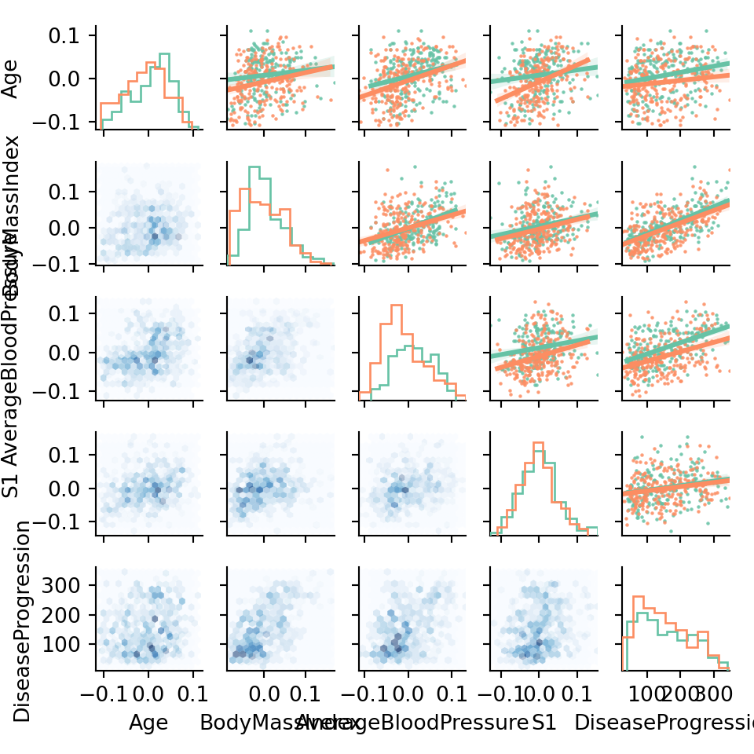

# Facet Plots

**Facet plots** revolutionized statistical graphics starting about 30 years ago

- Facet plots extend the number of dimensions projeted onto 2-d plot surface
- Key idea: Create array of plots of subsets of the data
  - Create subsets using a group-by operation on other variables
  - Lay out grid of plots on **same axis** by row and column grouping variables
  - Display same plot type for each group
  - Can add specific aesthetics, etc.